# Entregable 3 - Gabriela Eliana Rollano Málaga

# Análisis Factorial Exploratorio

# Explorar las correlaciones entre las variables

```r
# Es otra forma de reducir las dimensiones.
# Las cargas de correlaciones son diferentes a 0.
corMatrix_g = polycor::hetcor(factor_gabriela)$correlations
corMatrix_g
```

```
##                v2elembaut_ord v2mecrit_ord v2dlcountr_ord v2csreprss_ord
## v2elembaut_ord      1.0000000    0.7377899      0.6826106      0.7945379
## v2mecrit_ord        0.7377899    1.0000000      0.6917230      0.7422000
## v2dlcountr_ord      0.6826106    0.6917230      1.0000000      0.7146772
## v2csreprss_ord      0.7945379    0.7422000      0.7146772      1.0000000
## v2cseeorgs_ord      0.7581324    0.7667901      0.6945539      0.8888291
## v2cscnsult_ord      0.6429916    0.6375932      0.6675044      0.7144543
##                v2cseeorgs_ord v2cscnsult_ord
## v2elembaut_ord      0.7581324      0.6429916
## v2mecrit_ord        0.7667901      0.6375932
## v2dlcountr_ord      0.6945539      0.6675044
## v2csreprss_ord      0.8888291      0.7144543
## v2cseeorgs_ord      1.0000000      0.6812573
## v2cscnsult_ord      0.6812573      1.0000000
```

# Graficar la matriz de correlaciones

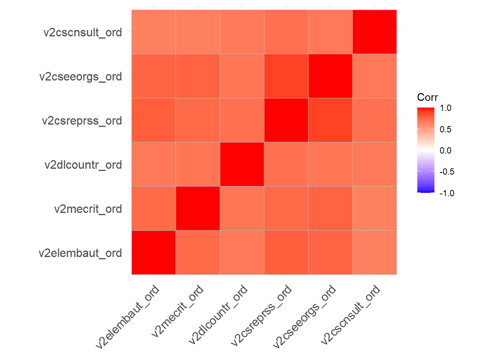

```r
# Para saber que las variables covarían se hace una matriz de correlaciones, nos dice que si una aumenta la otra también aumenta o viceversa.Vemos que hay variables que se correlacionan más que otras, pero en general todas se correlacionan bien.
ggcorrplot(corMatrix_g)
```

# Verificar validez del análisis factorial

# Verificar si variables se pueden factorizar

Overall MSA es mayor a 0.6, por lo que el análisis factorial es factible.

```r
psych::KMO(corMatrix_g)
```

```
## Kaiser-Meyer-Olkin factor adequacy
## Call: psych::KMO(r = corMatrix_g)
## Overall MSA =  0.91
## MSA for each item =
## v2elembaut_ord   v2mecrit_ord v2dlcountr_ord v2csreprss_ord v2cseeorgs_ord
##           0.93           0.93           0.94           0.85           0.86
## v2cscnsult_ord
##           0.95
```

# Descartar una posible matriz de identidad

Sale FALSE (p-value NO es mayor a 0.05), por lo que el análisis factorial es factible.

```r
# Queda comprobado que no es una matriz de identidad, que no se correlacionen entre sí mismas, sino con otras variables además de sí mismas y forman parte de un mismo concepto sin que haya relación de dependencia.
cortest.bartlett(corMatrix_g, n = nrow(factor_gabriela))$p.value>0.05
```

```
## [1] FALSE
```

# Descartar una posible matriz singular

Sale FALSE, por lo que el análisis factorial es factible.

```r
# Queda comprobado que no es una matriz singular.
is.singular.matrix(corMatrix_g)
```

```
## [1] FALSE
```

# Determinar en cuántos factores se pueden agrupar las variables

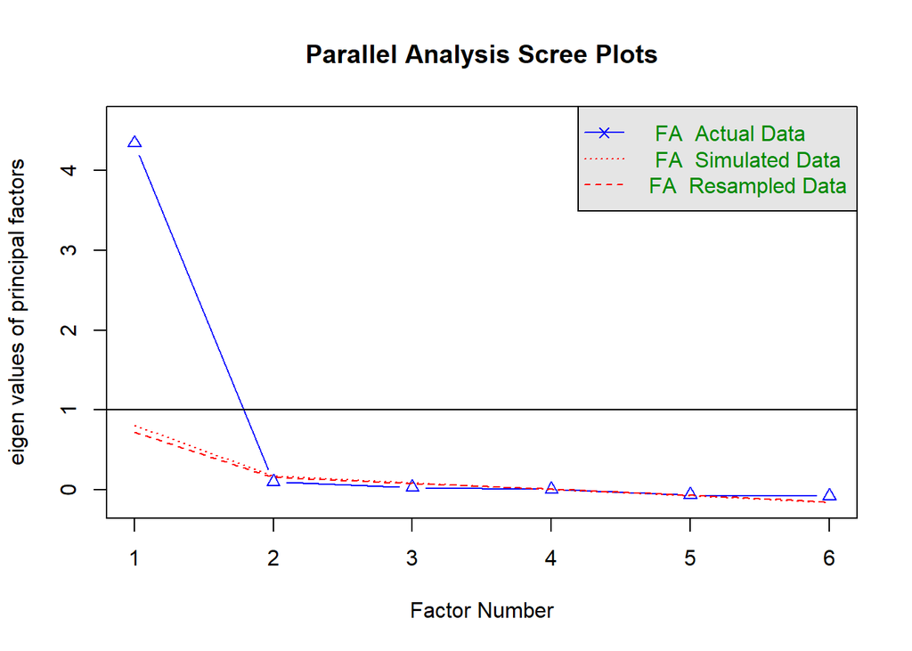

```
## Parallel analysis suggests that the number of factors =  1  and the number of components =  NA
```

```r
# Nos sugiere que el número de factores es 1.
fa.parallel(factor_gabriela, fm = "ML", fa = "fa")
```

# Observar las cargas factoriales y ver en qué factores se ubicaría cada variable

```r
#Observamos que el pocertanje de la varianza de las variables es de 72% lo cual está bastante bien. Nos explica la variación de las variables en conjunto, está explicando un 72%.
resfa_g <- fa(factor_gabriela, nfactors = 1, cor = "cor", rotate = "varimax", fm = "minres")
print(resfa_g$loadings, cutoff = 0.5)
```

```
##
## Loadings:
##                MR1
## v2elembaut_ord 0.852
## v2mecrit_ord   0.839
## v2dlcountr_ord 0.801
## v2csreprss_ord 0.925
## v2cseeorgs_ord 0.906
## v2cscnsult_ord 0.772
##
##                  MR1
## SS loadings    4.347
## Proportion Var 0.724
```

# Graficar cómo se agrupan las variables

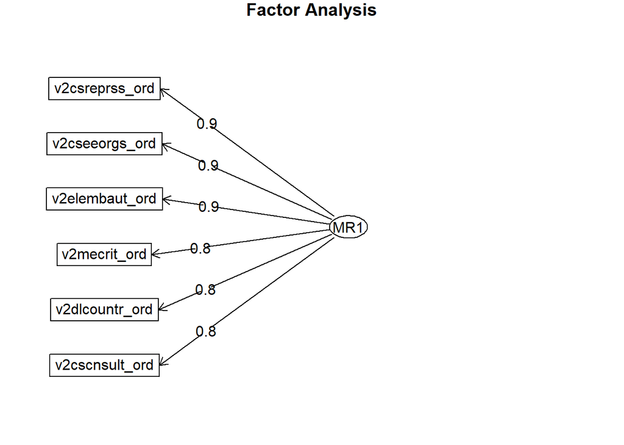

```r
# Hay un sólo factor que está detrás del comportamiento de esas 6 variables.
fa.diagram(resfa_g)
```

# Evaluar los resultados obtenidos

# ¿Qué variables aportaron más a los factores?

```r
# Las comunalidades no está diciendo qué porcentaje de las variables con las que estoy trabajando carga bien, la que menor carga es Consulta gubernamental hacia Organizaciones de Sociedad Civil con un 59.65%.
sort(resfa_g$communality)
```

```
## v2cscnsult_ord v2dlcountr_ord   v2mecrit_ord v2elembaut_ord v2cseeorgs_ord
##      0.5965095      0.6420975      0.7045047      0.7260622      0.8212054
## v2csreprss_ord
##      0.8563265
```

# Observar los posibles valores proyectados

# Para grabar en la base los puntajes de los factores

```r
factor_gabriela$puntaje = resfa_g$scores
```

# Análisis Factorial Confirmatorio

# Construir un modelo lineal

```r
modelog <- ' factorg  =~ v2elembaut_ord + v2mecrit_ord + v2dlcountr_ord + v2csreprss_ord + v2cseeorgs_ord + v2cscnsult_ord'
```

# Crear un objeto para hacer las validaciones

```r
cfa_fit <- cfa(modelog, data=factor_gabriela,
           std.lv=TRUE,
           missing="fiml")
```

# Preparar los test para las validaciones

```r
allParamCFA=parameterEstimates(cfa_fit,standardized = T)
allFitCFA=as.list(fitMeasures(cfa_fit))
```

# Ver si cada variable tiene una buena relación con su factor (p-value menor a 0.05 indica que la variable tiene buena relación con su latente)

```r
allParamCFA[allParamCFA$op=="=~",]
```

```
##       lhs op            rhs   est    se      z pvalue ci.lower ci.upper std.lv
## 1 factorg =~ v2elembaut_ord 1.219 0.088 13.906      0    1.048    1.391  1.219
## 2 factorg =~   v2mecrit_ord 0.715 0.054 13.356      0    0.610    0.820  0.715
## 3 factorg =~ v2dlcountr_ord 0.865 0.070 12.307      0    0.727    1.003  0.865
## 4 factorg =~ v2csreprss_ord 1.146 0.069 16.650      0    1.011    1.281  1.146
## 5 factorg =~ v2cseeorgs_ord 1.173 0.072 16.190      0    1.031    1.315  1.173
## 6 factorg =~ v2cscnsult_ord 0.509 0.043 11.907      0    0.425    0.593  0.509
##   std.all std.nox
## 1   0.845   0.845
## 2   0.824   0.824
## 3   0.780   0.780
## 4   0.940   0.940
## 5   0.925   0.925
## 6   0.762   0.762
```

# Ver si la asignación de variables ha relativamente buena (p-value mayor a 0.05 para validar el modelo)

```r
allFitCFA[c("chisq", "df", "pvalue")]
```

```
## $chisq
## [1] 29.68009
##
## $df
## [1] 9
##
## $pvalue
## [1] 0.0004972185
```

# Otra prueba para ver si el análisis factorial es relativamente bueno (índice Tucker - Lewi debe ser mayor a 0.9)

```r
allFitCFA$tli
```

```
## [1] 0.9634727
```

# Ver si la raíz del error cuadrático medio de aproximación es menor a 0.05 (ver rmsea)

```r
allFitCFA[c('rmsea.ci.lower','rmsea' ,'rmsea.ci.upper')]
```

```
## $rmsea.ci.lower
## [1] 0.06966505
##
## $rmsea
## [1] 0.1132996
##
## $rmsea.ci.upper
## [1] 0.1597871
```

# Hacer predicciones (scores) de las variables latentes

```r
scorescfa=normalize(lavPredict(cfa_fit),
                    method = "range",
                    margin=2, # by column
                    range = c(0, 10))
```

```r
factor_gabriela$prediccion = scorescfa
```

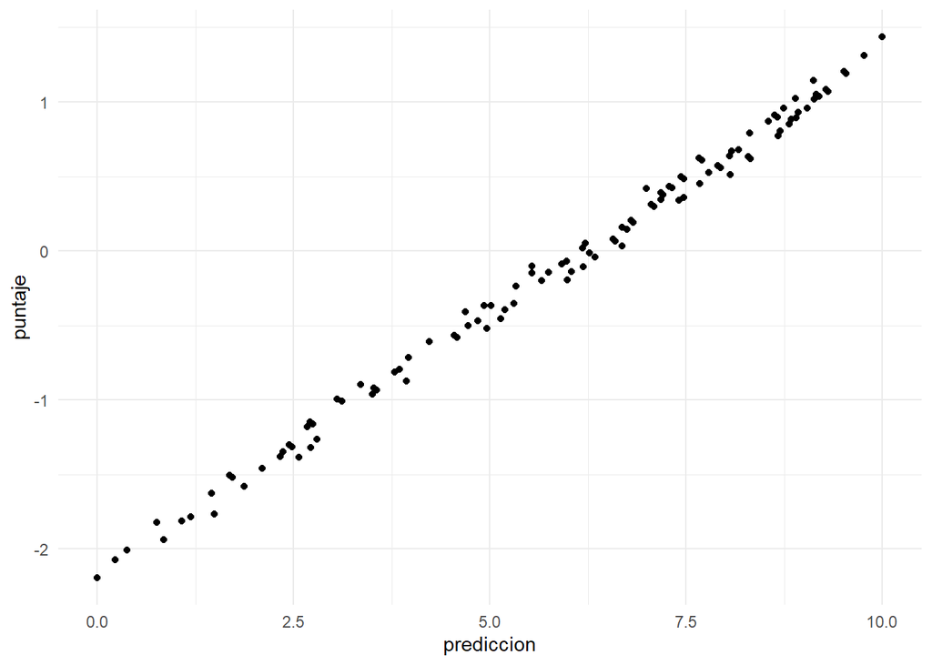

```r
ggplot(data=factor_gabriela,aes(x=prediccion,y=puntaje)) + geom_point() + theme_minimal()
```

```r
cluster_factor_gabriela = merge(dataClus, factor_gabriela$puntaje)
```